# Construindo um modelo e API para previsão dos preços de imóveis em Teresina - PI

Author

Prof. Dr. Pedro Rafael Diniz Marinho

# Modelagem imobiliária para dados de imóveis em Teresina - PI

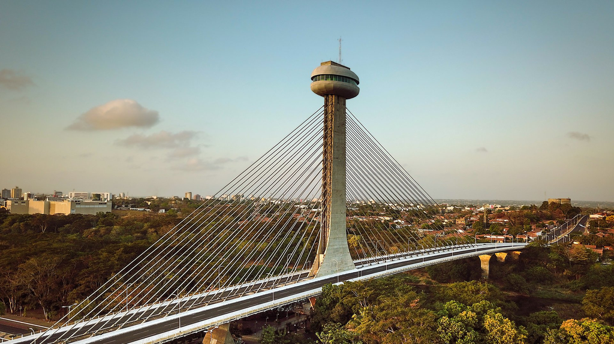

Iremos construir um modelo para previsão de valores 💲de imóveis usando o framework [**tidymodels**](https://www.tidymodels.org/) e disponibilizar uma API para consulta (previsão) dos preços de imóveis em Teresina - PI.

## Olhando para os dados

São dados reais, obtidos via web scraping do site [**Zap Imóveis**](https://www.zapimoveis.com.br/) 🏡🏢 no ano de 2023 do município de Teresina, Piauí, Brasil.

**Você poderá acessar os dados clicando** **AQUI** 💾.

Observa-se que as informações do `iptu` e `condiminio` são muito incipientes, e talvez, inputar essas informações não seja uma boa ideia, pois pode gerar um viés no modelo. Vamos descartar essas variáveis.

**Lista de veriáveis que serão descartadas:**

1. `endereço`: já há o georeferenciamento dos imóveis
2. `url`: sem utilidade para a previsão
3. `bairro`: já há o georeferenciamento dos imóveis
4. `iptu`: muitas observações faltantes
5. `condominio`: muitas observações faltantes
6. `comercio`: comercio também será descartado pois todas as informações estão como `FALSE`

📌 **Observações**:

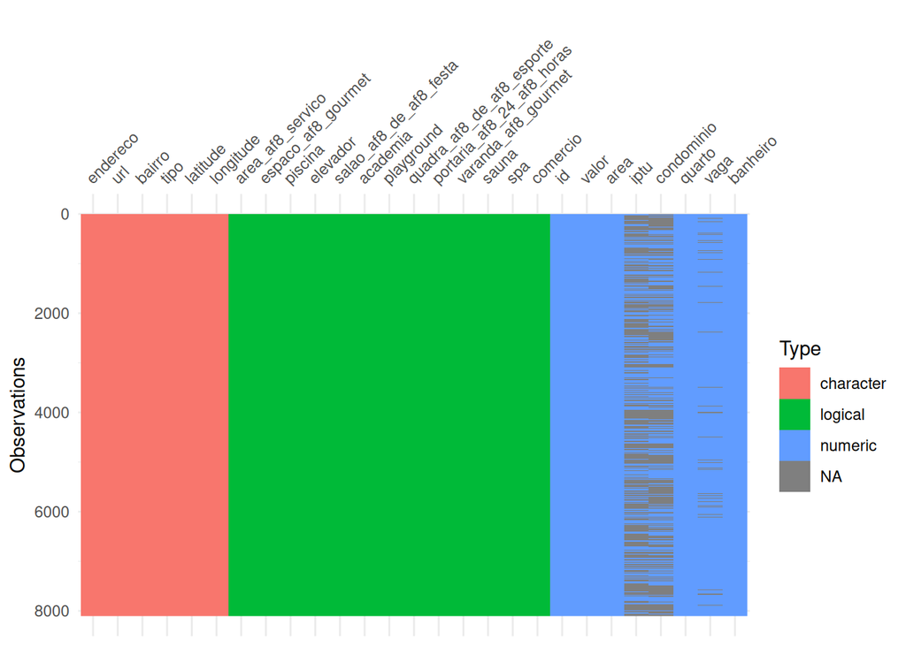

```r
library(tidymodels)
library(ggplot2)
library(vroom)
library(visdat)
library(future)
library(dplyr)
library(janitor)
library(iml)
library(patchwork)
library(pins)
library(vetiver)

# Resolvendo questões de ambiguidade de funções entre pacotes
tidymodels::tidymodels_prefer(quiet = TRUE)

# Definindo esquema de paralelização em todos os sistemas operacionais
# cores <- parallelly::availableCores(logical = FALSE)
# future::plan(future::multicore, workers = cores)

# Lendo dados
dados <- vroom::vroom("teresina.csv", show_col_types = FALSE) |>
  janitor::clean_names()

# Olhando rapidamente para os dados
visdat::vis_dat(dados)
```

```r
# Melhorando os nomes das colunas
dados <- dados |>
  janitor::clean_names()

dados <- dados |>
  dplyr::select(
    -id,
    -endereco,
    -url,
    -bairro,
    -iptu,
    -condominio,
    -comercio
  )

dados |>
  dplyr::count(tipo)
```

```
# A tibble: 6 × 2
  tipo                                  n
  <chr>                             <int>
1 apartamentos                       4804
2 casas                              1575
3 casas+AF8-de+AF8-condominio        1293
4 casas+AF8-de+AF8-vila                 1
5 flat                                  8
6 terrenos+AF8-lotes+AF8-condominio   423
```

```r
dados <-
  dados |>
  dplyr::mutate(
    tipo = dplyr::case_when(
      tipo == "apartamentos" ~ "apartamento",
      tipo == "casas" ~ "casa",
      tipo == "casas_de_condominio" ~ "casa",
      tipo == "casas_de_vila" ~ "casa",
      tipo == "flat" ~ "apartamento",
      TRUE ~ tipo
    )
  ) |>
  dplyr::mutate(valor = log10(valor))

dados <- dados |> filter(tipo %in% c("apartamento", "casa"))

dados |>
  dplyr::count(tipo)
```

```
# A tibble: 2 × 2
  tipo            n
  <chr>       <int>
1 apartamento  4812
2 casa         1575
```

Vamos agora visualizar os dados de uma forma que facilite a compreensão.

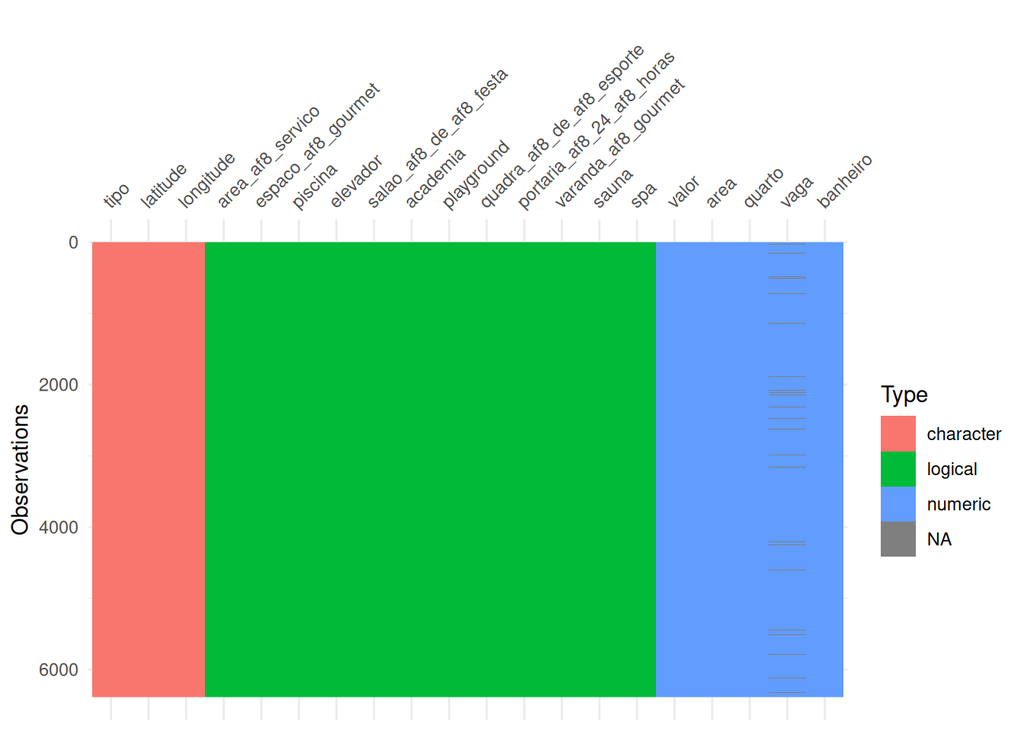

```r
library(visdat)
library(dplyr)
# Visualizando os dados (tipo, estrutura e valores ausentes)
visdat::vis_dat(dados)
```

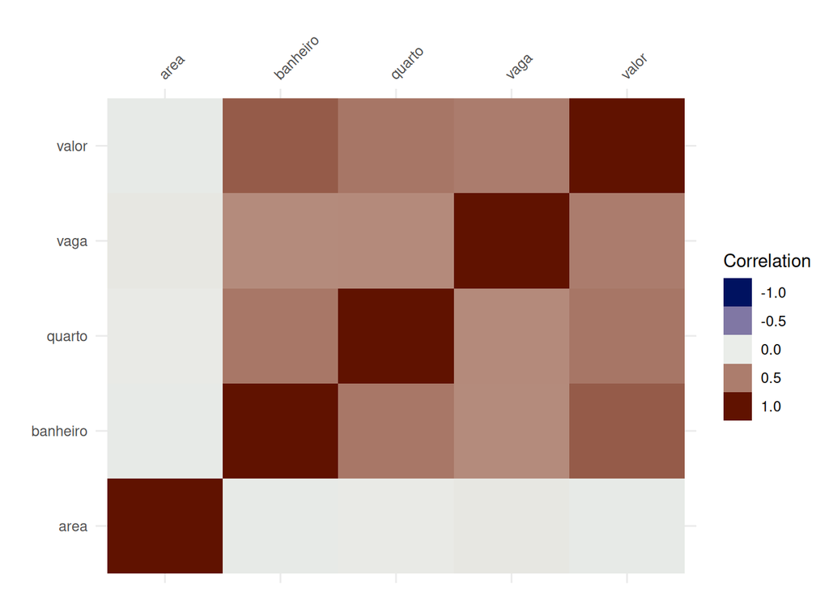

```r
# Selecionando apenas as variáveis numéricas
dados |>
  dplyr::select(where(is.numeric)) |>
  visdat::vis_cor(digits = 2, sort = TRUE)
```

Vamos observar os tipos de imóveis na variável `tipo` e fazer uma contagem nos tipos disponíveis:

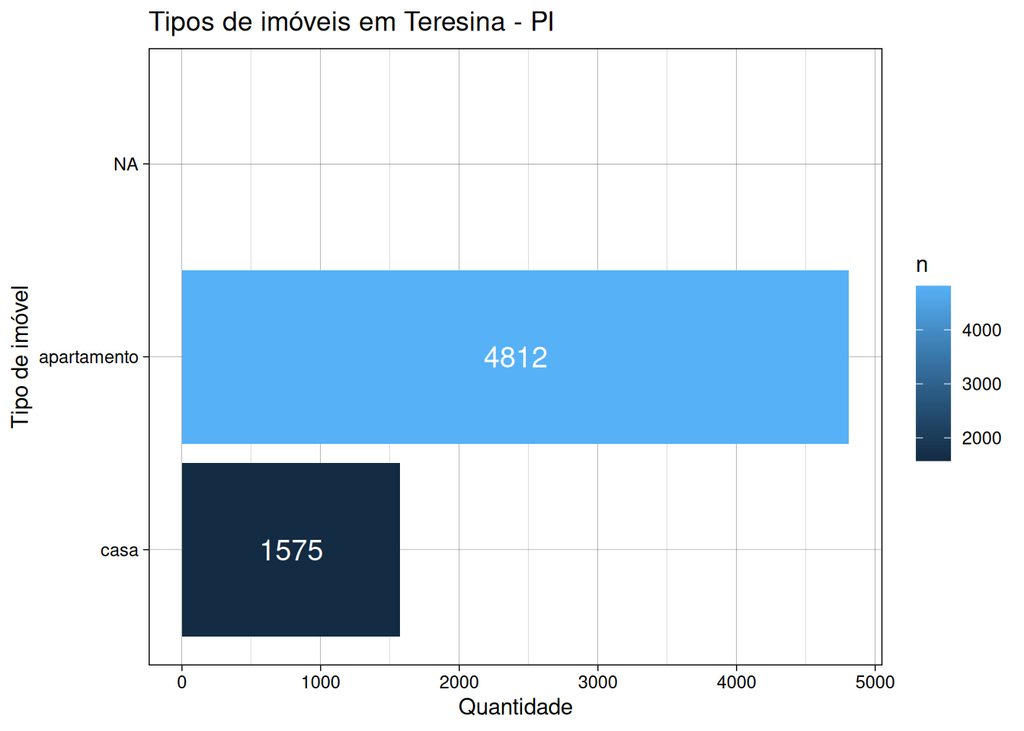

```r
# Tabela com a quantidade de tipos de imóveis
library(ggplot2)
library(dplyr)

# Contagem de tipos de imóveis
tipos_imoveis <-
  dados |>
  dplyr::count(tipo) |>
  dplyr::arrange(desc(n))

# Verificando os tipos de imóveis
p1 <-
  tipos_imoveis[1:4, ] |>
  dplyr::arrange(desc(n)) |>
  dplyr::mutate(tipo = forcats::fct_reorder(tipo, n)) |>
  ggplot(aes(x = tipo, y = n)) +
  geom_col(aes(fill = n)) +
  coord_flip() +
  geom_text(
    aes(label = n),
    position = position_stack(vjust = 0.5),
    color = "white",
    size = 5
  ) +
  labs(
    title = "Tipos de imóveis em Teresina - PI",
    x = "Tipo de imóvel",
    y = "Quantidade"
  ) +
  theme_linedraw()
# Gráfico com os tipos de imóveis
print(p1)
```

```r
# Tabela com os tipos de imóveis
print(tipos_imoveis)
```

```
# A tibble: 2 × 2
  tipo            n
  <chr>       <int>
1 apartamento  4812
2 casa         1575
```

# Holdout + modelo + conjunto de validação cruzada + receita

Aqui iremos dividir os dados em treino e teste, especificar o modelo, realizar a receita de pré-processamento e criar o conjunto de validação cruzada.

```r
set.seed(123)
# Dividindo os dados em treino e teste
dados_split <- initial_split(
  dados,
  prop = 0.8,
  strata = valor
)
treino <- training(dados_split)
teste <- testing(dados_split)

# Especificando o modelo
modelo <- rand_forest(mtry = tune(), min_n = tune()) |>
  set_engine("ranger") |>
  set_mode("regression")

# Realizando a receita de pré-processamento
receita <- recipe(valor ~ ., data = treino) |>
  recipes::step_log(
    all_numeric_predictors(),
    -latitude,
    -longitude,
    offset = 1L,
    base = 10
  ) |>
  recipes::step_impute_knn(
    all_numeric_predictors(),
    impute_with = imp_vars(area, banheiro, quarto, tipo)
  ) |>
  recipes::step_normalize(all_numeric_predictors()) |>
  recipes::step_corr(all_numeric_predictors()) |>
  recipes::step_dummy(all_nominal_predictors()) |>
  recipes::step_mutate(across(where(is.logical), .fns = as.numeric)) |>
  recipes::step_nzv(all_predictors())

dados_prep <- prep(receita) |> bake(new_data = NULL)

# Criando o conjunto de validação (5-fold cross-validation)
cv <- vfold_cv(
  treino,
  v = 5,
  strata = valor
)
```

# Definindo workflow e realizando a tunagem

```r
# Definindo o workflow (modelo + receita)
wf <- workflow() |>
  add_model(modelo) |>
  add_recipe(receita)

tunagem <-
  tune_grid(
    wf,
    resamples = cv,
    grid = 5,
    metrics = metric_set(yardstick::rmse, yardstick::rsq),
    control = control_grid(verbose = TRUE, parallel_over = "everything")
  )

# Ordenando os pseudo-r2 em ordem decrescente. Você poderia
# considerar o rmse (eu até prefiro).
tunagem |>
  collect_metrics(summarize = TRUE) |>
  dplyr::filter(.metric == "rsq") |>
  dplyr::arrange(desc(mean))
```

```
# A tibble: 5 × 8
   mtry min_n .metric .estimator  mean     n std_err .config
  <int> <int> <chr>   <chr>      <dbl> <int>   <dbl> <chr>
1    15    21 rsq     standard   0.823     5  0.0145 Preprocessor1_Model5
2     8     2 rsq     standard   0.822     5  0.0137 Preprocessor1_Model3
3    11    40 rsq     standard   0.821     5  0.0146 Preprocessor1_Model4
4     4    30 rsq     standard   0.819     5  0.0145 Preprocessor1_Model2
5     1    11 rsq     standard   0.730     5  0.0131 Preprocessor1_Model1
```

```r
# Melhor modelo
melhor_hiperparametro <- tunagem |>
  select_best(metric = "rsq")

# Finalizando o workflow, retreinando com todos os dados
# do conjunto de treino e avaliando nos dados independentes
# de teste.
wf_final <- wf |>
  finalize_workflow(melhor_hiperparametro) |>
  last_fit(split = dados_split)

# Avaliação imparcial no conjunto de teste
wf_final |>
  collect_metrics(summarize = TRUE)
```

```
# A tibble: 2 × 4
  .metric .estimator .estimate .config
  <chr>   <chr>          <dbl> <chr>
1 rmse    standard       0.129 Preprocessor1_Model1
2 rsq     standard       0.848 Preprocessor1_Model1
```

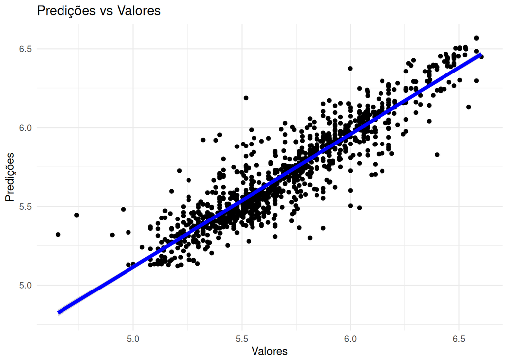

```r
# Plotando as real vs previsões
wf_final |>
  collect_predictions() |>
  ggplot(aes(x = valor, y = .pred)) +
  geom_point() +
  geom_smooth(method = "lm", color = "blue", linewidth = 1.7) +
  theme_minimal() +
  labs(
    title = "Predições vs Valores",
    x = "Valores",
    y = "Predições"
  )
```

# Outras análises

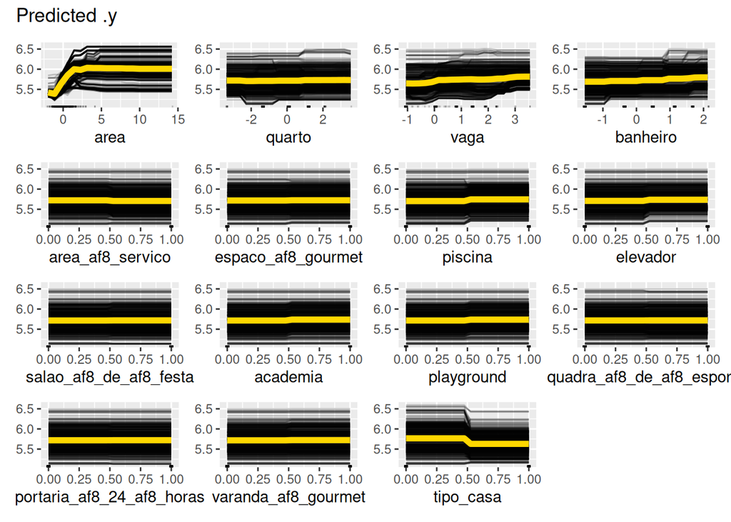

```r
d <- prep(receita) |> bake(new_data = teste[sample(500L), ])
x <- dplyr::select(d, -valor)

# Realizando análise das variáveis ---------------------------------------
preditor <- iml::Predictor$new(
  extract_fit_parsnip(wf_final),
  data = x,
  y = d$valor
)

efeito <- iml::FeatureEffects$new(preditor, method = "pdp+ice")
p1 <- efeito$plot()

imp <- iml::FeatureImp$new(preditor, loss = "rmse")
p2 <- imp$plot()

print(p1)
```

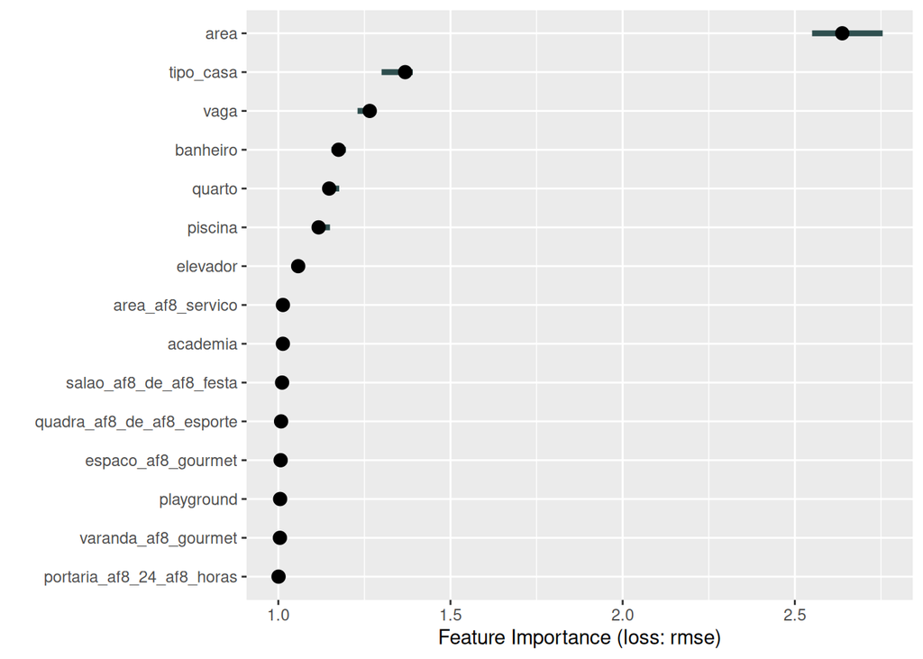

```r
print(p2)
```

# Construindo uma API

Criando arquivos ṕara disponibilizar o modelo como uma API usando o pacote [**vetiver**](https://vetiver.posit.co/). É possível rodar a API localmente com o arqivo `api.r` ou criar uma imagem Docker para rodar a API em um container.

```r
#! Criando uma api vetiver
modelo_vetiver <-
  vetiver::vetiver_model(
    extract_workflow(wf_final),
    "modelo_teresina"
  )

# Criando o board para poder pinar o modelo
board <- pins::board_folder(
  path = "modelo_teresina"
)

#! Pinando o modelo
vetiver::vetiver_pin_write(
  board = board,
  vetiver_model = modelo_vetiver
)

#* Criando uma API com o vetiver
# pr <- vetiver::vetiver_api(plumber::pr(), modelo_vetiver)
# vetiver::vetiver_api(plumber::pr(), modelo_vetiver)$run(port = 8080)

# Gerando o arquivo plumber para rodar a API

vetiver::vetiver_write_plumber(
  board = board,
  name = "modelo_teresina",
  file = "api.r"
)

# Rodando o arquivo api.r em segundo plano
# call::r_bg não trava o console.
# api <- callr::r_bg(
#   function() {
#     plumber::plumb("api.r")$run(port = 8000)
#   }
# )

# Preparando um arquivo Dockerfile
vetiver::vetiver_prepare_docker(
  board = board,
  name = "modelo_teresina",
  version = NULL,
  docker_args = list(port = 8000)
)
```